# Lab 08: Modeling Data 1

Johanna Ravenhurst

2022-11-09 - 2022-11-12

```r
require(here)
require(palmerpenguins)
#install.packages('simpleboot')
require(simpleboot)
require(boot)
```

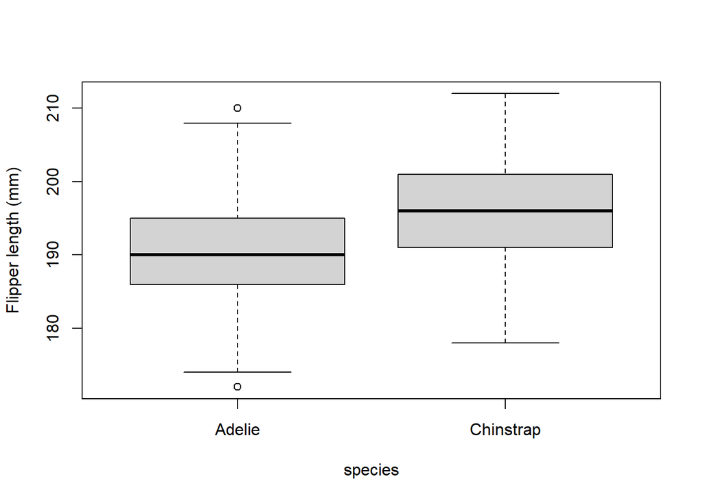

```r
#Remove Gentoo penguins using droplevels

penguin_dat = droplevels(subset(penguins, species != "Gentoo"))
{
  boxplot(
    flipper_length_mm ~ species, data = penguin_dat,
    ylab = "Flipper length (mm)")
}
```

```r
veg = read.csv(here("data", "vegdata.csv"))
head(veg)
```

```
##   block plot date treatment birch pine fern
## 1     A   A3 1995   control     0    4  260
## 2     A   A7 1995   control     0    0  186
## 3     A   A4 1995   removed     8    8   46
## 4     A   A6 1995   removed     6   28    1
## 5     A   A5 1995     mixed     0    1  309
## 6     A   A8 1995     mixed     0    0  258
```

```r
dat_bird = read.csv(here("data", "bird.sub.csv"))
dat_habitat = read.csv(here("data", "hab.sub.csv"))

#Merge in to dat_all
dat_all = merge(
  dat_bird,
  dat_habitat,
  by = c("basin", "sub"))
```

#Note: Walkthrough examples not included in html output

#Parametric Two-Sample Test

#Bootstrap Two-Sample Test

#Tree Data

#Nonparametric two-sample test - wilcox

#Boostrap of tree data

#Bird Data: linear model

#Z-standardization

#Model Variables

#Simple Linear Regression

#Resampling our data: Our goal is to use resampling techniques, Monte Carlo and bootstrapping, to characterize the null and alternative distributions.

#Null Distribution: Monte Carlo Simulation

#Monte Carlo Randomization Loop

#Critical Slope Value

#Alternative Distribution: Bootstrapping

#Plot both null and alternative distributions - use density plots

#Lab Questions

#Penguin Boot Q1-4

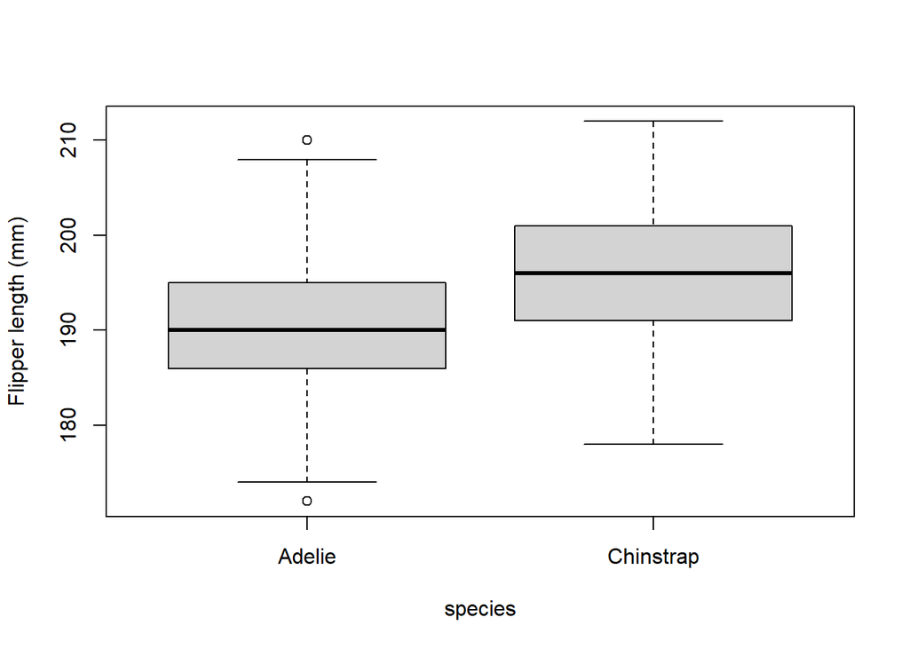

```r
#Remove Gentoo penguins using droplevels
penguin_dat = droplevels(subset(penguins, species != "Gentoo"))
{
  boxplot(
    flipper_length_mm ~ species, data = penguin_dat,
    ylab = "Flipper length (mm)")
}
```

```r
summary(penguin_dat$flipper_length_mm)
```

```
##    Min. 1st Qu.  Median    Mean 3rd Qu.    Max.    NA's
##   172.0   187.0   191.0   191.8   196.0   212.0       1
```

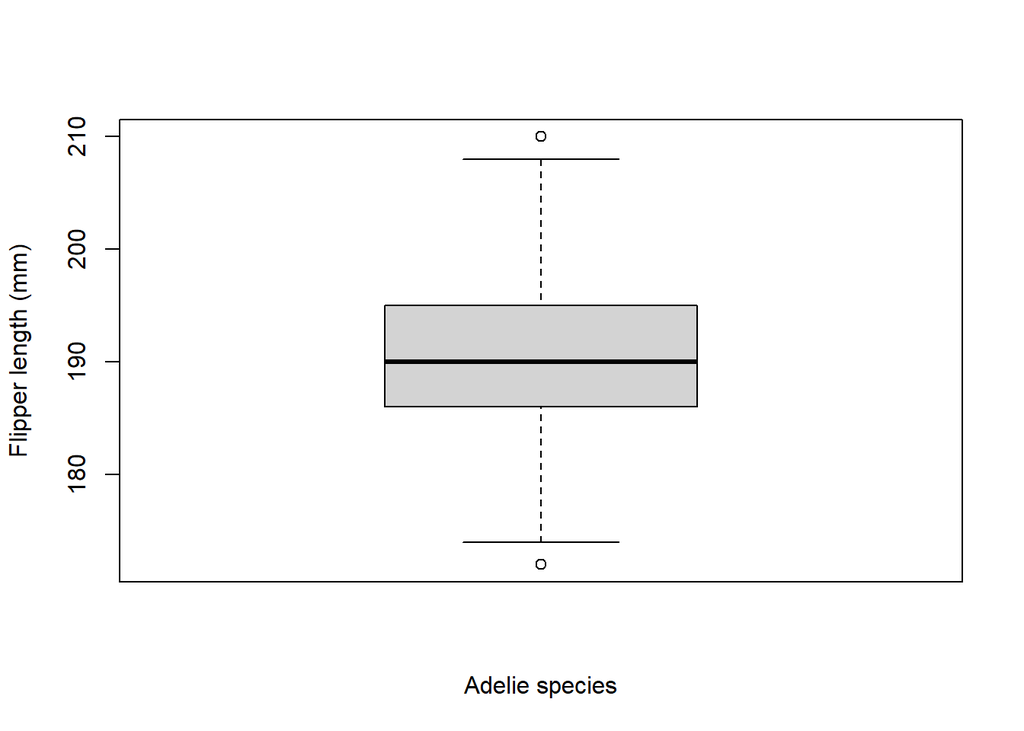

```r
#1 NA value



boot_mean = function(x, i)
{
  return(mean(x[i], na.rm = TRUE))
}
#As explained in the Lab 07 walkthrough, we have to use our boot_mean() function, rather than mean() within our call to two.boot(). We need to do this to account for the na value (we know there is 1 for this variable).

sample1_dat <- droplevels(subset(penguin_dat, species != "Chinstrap"))
sample2_dat <- droplevels(subset(penguin_dat, species != "Adelie"))
#Note: I'm guessing there is an easier way to subset the data for each species for the two.boot function, but this is what I could come up with...

 boxplot(
    flipper_length_mm ~ species, data = sample1_dat,
    ylab = "Flipper length (mm)",
    xlab = "Adelie species")
```